# **House Prices Kaggle Competition - EDA**

## **Data Dictionary**

MSSubClass: Identifies the type of dwelling involved in the sale.

```
    20	1-STORY 1946 & NEWER ALL STYLES
    30	1-STORY 1945 & OLDER
    40	1-STORY W/FINISHED ATTIC ALL AGES
    45	1-1/2 STORY - UNFINISHED ALL AGES
    50	1-1/2 STORY FINISHED ALL AGES
    60	2-STORY 1946 & NEWER
    70	2-STORY 1945 & OLDER
    75	2-1/2 STORY ALL AGES
    80	SPLIT OR MULTI-LEVEL
    85	SPLIT FOYER
    90	DUPLEX - ALL STYLES AND AGES
   120	1-STORY PUD (Planned Unit Development) - 1946 & NEWER
   150	1-1/2 STORY PUD - ALL AGES
   160	2-STORY PUD - 1946 & NEWER
   180	PUD - MULTILEVEL - INCL SPLIT LEV/FOYER
   190	2 FAMILY CONVERSION - ALL STYLES AND AGES
```

MSZoning: Identifies the general zoning classification of the sale.

```
   A	Agriculture
   C	Commercial
   FV	Floating Village Residential
   I	Industrial
   RH	Residential High Density
   RL	Residential Low Density
   RP	Residential Low Density Park
   RM	Residential Medium Density
```

LotFrontage: Linear feet of street connected to property

LotArea: Lot size in square feet

Street: Type of road access to property

```
   Grvl	Gravel
   Pave	Paved
```

Alley: Type of alley access to property

```
   Grvl	Gravel
   Pave	Paved
   NA 	No alley access
```

LotShape: General shape of property

```
   Reg	Regular
   IR1	Slightly irregular
   IR2	Moderately Irregular
   IR3	Irregular
```

LandContour: Flatness of the property

```
   Lvl	Near Flat/Level
   Bnk	Banked - Quick and significant rise from street grade to building
   HLS	Hillside - Significant slope from side to side
   Low	Depression
```

Utilities: Type of utilities available

```
   AllPub	All public Utilities (E,G,W,& S)
   NoSewr	Electricity, Gas, and Water (Septic Tank)
   NoSeWa	Electricity and Gas Only
   ELO	Electricity only
```

LotConfig: Lot configuration

```
   Inside	Inside lot
   Corner	Corner lot
   CulDSac	Cul-de-sac
   FR2	Frontage on 2 sides of property
   FR3	Frontage on 3 sides of property
```

LandSlope: Slope of property

```
   Gtl	Gentle slope
   Mod	Moderate Slope
   Sev	Severe Slope
```

Neighborhood: Physical locations within Ames city limits

```
   Blmngtn	Bloomington Heights
   Blueste	Bluestem
   BrDale	Briardale
   BrkSide	Brookside
   ClearCr	Clear Creek
   CollgCr	College Creek
   Crawfor	Crawford
   Edwards	Edwards
   Gilbert	Gilbert
   IDOTRR	Iowa DOT and Rail Road
   MeadowV	Meadow Village
   Mitchel	Mitchell
   Names	North Ames
   NoRidge	Northridge
   NPkVill	Northpark Villa
   NridgHt	Northridge Heights
   NWAmes	Northwest Ames
   OldTown	Old Town
   SWISU	South & West of Iowa State University
   Sawyer	Sawyer
   SawyerW	Sawyer West
   Somerst	Somerset
   StoneBr	Stone Brook
   Timber	Timberland
   Veenker	Veenker
```

Condition1: Proximity to various conditions

```
   Artery	Adjacent to arterial street
   Feedr	Adjacent to feeder street
   Norm	Normal
   RRNn	Within 200' of North-South Railroad
   RRAn	Adjacent to North-South Railroad
   PosN	Near positive off-site feature--park, greenbelt, etc.
   PosA	Adjacent to postive off-site feature
   RRNe	Within 200' of East-West Railroad
   RRAe	Adjacent to East-West Railroad
```

Condition2: Proximity to various conditions (if more than one is present)

```
   Artery	Adjacent to arterial street
   Feedr	Adjacent to feeder street
   Norm	Normal
   RRNn	Within 200' of North-South Railroad
   RRAn	Adjacent to North-South Railroad
   PosN	Near positive off-site feature--park, greenbelt, etc.
   PosA	Adjacent to postive off-site feature
   RRNe	Within 200' of East-West Railroad
   RRAe	Adjacent to East-West Railroad
```

BldgType: Type of dwelling

```
   1Fam	Single-family Detached
   2FmCon	Two-family Conversion; originally built as one-family dwelling
   Duplx	Duplex
   TwnhsE	Townhouse End Unit
   TwnhsI	Townhouse Inside Unit
```

HouseStyle: Style of dwelling

```
   1Story	One story
   1.5Fin	One and one-half story: 2nd level finished
   1.5Unf	One and one-half story: 2nd level unfinished
   2Story	Two story
   2.5Fin	Two and one-half story: 2nd level finished
   2.5Unf	Two and one-half story: 2nd level unfinished
   SFoyer	Split Foyer
   SLvl	Split Level
```

OverallQual: Rates the overall material and finish of the house

```
   10	Very Excellent
   9	Excellent
   8	Very Good
   7	Good
   6	Above Average
   5	Average
   4	Below Average
   3	Fair
   2	Poor
   1	Very Poor
```

OverallCond: Rates the overall condition of the house

```
   10	Very Excellent
   9	Excellent
   8	Very Good
   7	Good
   6	Above Average
   5	Average
   4	Below Average
   3	Fair
   2	Poor
   1	Very Poor
```

YearBuilt: Original construction date

YearRemodAdd: Remodel date (same as construction date if no remodeling or additions)

RoofStyle: Type of roof

```
   Flat	Flat
   Gable	Gable
   Gambrel	Gabrel (Barn)
   Hip	Hip
   Mansard	Mansard
   Shed	Shed
```

RoofMatl: Roof material

```
   ClyTile	Clay or Tile
   CompShg	Standard (Composite) Shingle
   Membran	Membrane
   Metal	Metal
   Roll	Roll
   Tar&Grv	Gravel & Tar
   WdShake	Wood Shakes
   WdShngl	Wood Shingles
```

Exterior1st: Exterior covering on house

```
   AsbShng	Asbestos Shingles
   AsphShn	Asphalt Shingles
   BrkComm	Brick Common
   BrkFace	Brick Face
   CBlock	Cinder Block
   CemntBd	Cement Board
   HdBoard	Hard Board
   ImStucc	Imitation Stucco
   MetalSd	Metal Siding
   Other	Other
   Plywood	Plywood
   PreCast	PreCast
   Stone	Stone
   Stucco	Stucco
   VinylSd	Vinyl Siding
   Wd Sdng	Wood Siding
   WdShing	Wood Shingles
```

Exterior2nd: Exterior covering on house (if more than one material)

```
   AsbShng	Asbestos Shingles
   AsphShn	Asphalt Shingles
   BrkComm	Brick Common
   BrkFace	Brick Face
   CBlock	Cinder Block
   CemntBd	Cement Board
   HdBoard	Hard Board
   ImStucc	Imitation Stucco
   MetalSd	Metal Siding
   Other	Other
   Plywood	Plywood
   PreCast	PreCast
   Stone	Stone
   Stucco	Stucco
   VinylSd	Vinyl Siding
   Wd Sdng	Wood Siding
   WdShing	Wood Shingles
```

MasVnrType: Masonry veneer type

```
   BrkCmn	Brick Common
   BrkFace	Brick Face
   CBlock	Cinder Block
   None	None
   Stone	Stone
```

MasVnrArea: Masonry veneer area in square feet

ExterQual: Evaluates the quality of the material on the exterior

```
   Ex	Excellent
   Gd	Good
   TA	Average/Typical
   Fa	Fair
   Po	Poor
```

ExterCond: Evaluates the present condition of the material on the exterior

```
   Ex	Excellent
   Gd	Good
   TA	Average/Typical
   Fa	Fair
   Po	Poor
```

Foundation: Type of foundation

```
   BrkTil	Brick & Tile
   CBlock	Cinder Block
   PConc	Poured Contrete
   Slab	Slab
   Stone	Stone
   Wood	Wood
```

BsmtQual: Evaluates the height of the basement

```
   Ex	Excellent (100+ inches)
   Gd	Good (90-99 inches)
   TA	Typical (80-89 inches)
   Fa	Fair (70-79 inches)
   Po	Poor (<70 inches
   NA	No Basement
```

BsmtCond: Evaluates the general condition of the basement

```
   Ex	Excellent
   Gd	Good
   TA	Typical - slight dampness allowed
   Fa	Fair - dampness or some cracking or settling
   Po	Poor - Severe cracking, settling, or wetness
   NA	No Basement
```

BsmtExposure: Refers to walkout or garden level walls

```
   Gd	Good Exposure
   Av	Average Exposure (split levels or foyers typically score average or above)
   Mn	Mimimum Exposure
   No	No Exposure
   NA	No Basement
```

BsmtFinType1: Rating of basement finished area

```
   GLQ	Good Living Quarters
   ALQ	Average Living Quarters
   BLQ	Below Average Living Quarters
   Rec	Average Rec Room
   LwQ	Low Quality
   Unf	Unfinshed
   NA	No Basement
```

BsmtFinSF1: Type 1 finished square feet

BsmtFinType2: Rating of basement finished area (if multiple types)

```
   GLQ	Good Living Quarters
   ALQ	Average Living Quarters
   BLQ	Below Average Living Quarters
   Rec	Average Rec Room
   LwQ	Low Quality
   Unf	Unfinshed
   NA	No Basement
```

BsmtFinSF2: Type 2 finished square feet

BsmtUnfSF: Unfinished square feet of basement area

TotalBsmtSF: Total square feet of basement area

Heating: Type of heating

```
   Floor	Floor Furnace
   GasA	Gas forced warm air furnace
   GasW	Gas hot water or steam heat
   Grav	Gravity furnace
   OthW	Hot water or steam heat other than gas
   Wall	Wall furnace
```

HeatingQC: Heating quality and condition

```
   Ex	Excellent
   Gd	Good
   TA	Average/Typical
   Fa	Fair
   Po	Poor
```

CentralAir: Central air conditioning

```
   N	No
   Y	Yes
```

Electrical: Electrical system

```
   SBrkr	Standard Circuit Breakers & Romex
   FuseA	Fuse Box over 60 AMP and all Romex wiring (Average)
   FuseF	60 AMP Fuse Box and mostly Romex wiring (Fair)
   FuseP	60 AMP Fuse Box and mostly knob & tube wiring (poor)
   Mix	Mixed
```

1stFlrSF: First Floor square feet

2ndFlrSF: Second floor square feet

LowQualFinSF: Low quality finished square feet (all floors)

GrLivArea: Above grade (ground) living area square feet

BsmtFullBath: Basement full bathrooms

BsmtHalfBath: Basement half bathrooms

FullBath: Full bathrooms above grade

HalfBath: Half baths above grade

Bedroom: Bedrooms above grade (does NOT include basement bedrooms)

Kitchen: Kitchens above grade

KitchenQual: Kitchen quality

```
   Ex	Excellent
   Gd	Good
   TA	Typical/Average
   Fa	Fair
   Po	Poor
```

TotRmsAbvGrd: Total rooms above grade (does not include bathrooms)

Functional: Home functionality (Assume typical unless deductions are warranted)

```
   Typ	Typical Functionality
   Min1	Minor Deductions 1
   Min2	Minor Deductions 2
   Mod	Moderate Deductions
   Maj1	Major Deductions 1
   Maj2	Major Deductions 2
   Sev	Severely Damaged
   Sal	Salvage only
```

Fireplaces: Number of fireplaces

FireplaceQu: Fireplace quality

```
   Ex	Excellent - Exceptional Masonry Fireplace
   Gd	Good - Masonry Fireplace in main level
   TA	Average - Prefabricated Fireplace in main living area or Masonry Fireplace in basement
   Fa	Fair - Prefabricated Fireplace in basement
   Po	Poor - Ben Franklin Stove
   NA	No Fireplace
```

GarageType: Garage location

```
   2Types	More than one type of garage
   Attchd	Attached to home
   Basment	Basement Garage
   BuiltIn	Built-In (Garage part of house - typically has room above garage)
   CarPort	Car Port
   Detchd	Detached from home
   NA	No Garage
```

GarageYrBlt: Year garage was built

GarageFinish: Interior finish of the garage

```
   Fin	Finished
   RFn	Rough Finished
   Unf	Unfinished
   NA	No Garage
```

GarageCars: Size of garage in car capacity

GarageArea: Size of garage in square feet

GarageQual: Garage quality

```
   Ex	Excellent
   Gd	Good
   TA	Typical/Average
   Fa	Fair
   Po	Poor
   NA	No Garage
```

GarageCond: Garage condition

```
   Ex	Excellent
   Gd	Good
   TA	Typical/Average
   Fa	Fair
   Po	Poor
   NA	No Garage
```

PavedDrive: Paved driveway

```
   Y	Paved
   P	Partial Pavement
   N	Dirt/Gravel
```

WoodDeckSF: Wood deck area in square feet

OpenPorchSF: Open porch area in square feet

EnclosedPorch: Enclosed porch area in square feet

3SsnPorch: Three season porch area in square feet

ScreenPorch: Screen porch area in square feet

PoolArea: Pool area in square feet

PoolQC: Pool quality

```
   Ex	Excellent
   Gd	Good
   TA	Average/Typical
   Fa	Fair
   NA	No Pool
```

Fence: Fence quality

```
   GdPrv	Good Privacy
   MnPrv	Minimum Privacy
   GdWo	Good Wood
   MnWw	Minimum Wood/Wire
   NA	No Fence
```

MiscFeature: Miscellaneous feature not covered in other categories

```
   Elev	Elevator
   Gar2	2nd Garage (if not described in garage section)
   Othr	Other
   Shed	Shed (over 100 SF)
   TenC	Tennis Court
   NA	None
```

MiscVal: $Value of miscellaneous feature

MoSold: Month Sold (MM)

YrSold: Year Sold (YYYY)

SaleType: Type of sale

```
   WD 	Warranty Deed - Conventional
   CWD	Warranty Deed - Cash
   VWD	Warranty Deed - VA Loan
   New	Home just constructed and sold
   COD	Court Officer Deed/Estate
   Con	Contract 15% Down payment regular terms
   ConLw	Contract Low Down payment and low interest
   ConLI	Contract Low Interest
   ConLD	Contract Low Down
   Oth	Other
```

SaleCondition: Condition of sale

```
   Normal	Normal Sale
   Abnorml	Abnormal Sale -  trade, foreclosure, short sale
   AdjLand	Adjoining Land Purchase
   Alloca	Allocation - two linked properties with separate deeds, typically condo with a garage unit
   Family	Sale between family members
   Partial	Home was not completed when last assessed (associated with New Homes)
```

## **Initial Setup**

**Check and install the dependencies**

```python
!curl -sSL https://raw.githubusercontent.com/K14aNB/house-prices-kaggle-competition/main/requirements.txt
```

```
mlflow
pandas==2.2.2
scikit-learn==1.4.2
seaborn==0.13.1
PyYAML
xgboost
env_setup @ git+https://github.com/K14aNB/setup-notebook-environment.git@main
```

```python
%%capture
# Run this command in terminal before running this notebook as .py script
# Installs dependencies from requirements.txt present in the repo
!pip install -r https://raw.githubusercontent.com/K14aNB/house-prices-kaggle-competition/main/requirements.txt
```

**Import the libraries**

```python
import numpy as np
import pandas as pd
import matplotlib.pyplot as plt
import seaborn as sns
from sklearn.impute import SimpleImputer
from sklearn.preprocessing import OrdinalEncoder,LabelEncoder
from sklearn.model_selection import train_test_split
from sklearn.feature_selection import mutual_info_regression
import pickle
import env_setup
import os
```

**Environment Setup**

```python
result_path=env_setup.setup(repo_name='house-prices-kaggle-competition',nb_name='House-Prices-Kaggle-Competition-EDA')
```

```
Found the repo
MLFlow setup with Dagshub is done!!
```

**Read the data**

```python
housing_data=pd.read_csv(os.path.join(result_path,'train.csv'))
```

```python
housing_data.head()
```

|  | Id | MSSubClass | MSZoning | LotFrontage | LotArea | Street | Alley | LotShape | LandContour | Utilities | ... | PoolArea | PoolQC | Fence | MiscFeature | MiscVal | MoSold | YrSold | SaleType | SaleCondition | SalePrice |
| --- | --- | --- | --- | --- | --- | --- | --- | --- | --- | --- | --- | --- | --- | --- | --- | --- | --- | --- | --- | --- | --- |
| 0 | 1 | 60 | RL | 65.0 | 8450 | Pave | NaN | Reg | Lvl | AllPub | ... | 0 | NaN | NaN | NaN | 0 | 2 | 2008 | WD | Normal | 208500 |
| 1 | 2 | 20 | RL | 80.0 | 9600 | Pave | NaN | Reg | Lvl | AllPub | ... | 0 | NaN | NaN | NaN | 0 | 5 | 2007 | WD | Normal | 181500 |
| 2 | 3 | 60 | RL | 68.0 | 11250 | Pave | NaN | IR1 | Lvl | AllPub | ... | 0 | NaN | NaN | NaN | 0 | 9 | 2008 | WD | Normal | 223500 |
| 3 | 4 | 70 | RL | 60.0 | 9550 | Pave | NaN | IR1 | Lvl | AllPub | ... | 0 | NaN | NaN | NaN | 0 | 2 | 2006 | WD | Abnorml | 140000 |
| 4 | 5 | 60 | RL | 84.0 | 14260 | Pave | NaN | IR1 | Lvl | AllPub | ... | 0 | NaN | NaN | NaN | 0 | 12 | 2008 | WD | Normal | 250000 |

5 rows × 81 columns

```python
housing_data.info()
```

```
<class 'pandas.core.frame.DataFrame'>
RangeIndex: 1460 entries, 0 to 1459
Data columns (total 81 columns):
 #   Column         Non-Null Count  Dtype
---  ------         --------------  -----
 0   Id             1460 non-null   int64
 1   MSSubClass     1460 non-null   int64
 2   MSZoning       1460 non-null   object
 3   LotFrontage    1201 non-null   float64
 4   LotArea        1460 non-null   int64
 5   Street         1460 non-null   object
 6   Alley          91 non-null     object
 7   LotShape       1460 non-null   object
 8   LandContour    1460 non-null   object
 9   Utilities      1460 non-null   object
```

[output cut: 73 more lines]

## **Exploratory Data Analysis**

**Check for missing values**

```python
housing_data.isna().sum()
```

```
Id                 0
MSSubClass         0
MSZoning           0
LotFrontage      259
LotArea            0
                ...
MoSold             0
YrSold             0
SaleType           0
SaleCondition      0
SalePrice          0
Length: 81, dtype: int64
```

```python
# Find out the columns with missing values
missing_value_cols=[col for col in housing_data.columns if housing_data[col].isna().sum()>0]
missing_values=[housing_data[col].isna().sum() for col in housing_data if housing_data[col].isna().sum()>0]
cols_with_missing_values=dict(zip(missing_value_cols,missing_values))
cols_with_missing_values
```

```
{'LotFrontage': 259,
 'Alley': 1369,
 'MasVnrType': 872,
 'MasVnrArea': 8,
 'BsmtQual': 37,
 'BsmtCond': 37,
 'BsmtExposure': 38,
 'BsmtFinType1': 37,
 'BsmtFinType2': 38,
 'Electrical': 1,
 'FireplaceQu': 690,
 'GarageType': 81,
 'GarageYrBlt': 81,
 'GarageFinish': 81,
 'GarageQual': 81,
 'GarageCond': 81,
 'PoolQC': 1453,
 'Fence': 1179,
 'MiscFeature': 1406}
```

Columns like `Alley`,`MasVnrType`,`PoolQC`, `Fence`,`MiscFeature` can be dropped due to high percentage of missing values.

**Check for duplicated rows**

```python
housing_data.duplicated().sum().sum()
```

```
0
```

**Utility Function to help with Visualization**

```python
def visualize(plot:str,x:str,data:str,xlabel:str,y:str=None,hue:str=None,ylabel:str=None):
    '''
    '''
    fig=plt.figure(figsize=(10,5))

    if plot=='scatter' and y is not None:
        if hue is not None:
            sns.scatterplot(x=x,y=y,hue=hue,data=data)
        else:
            sns.scatterplot(x=x,y=y,data=data)
        plt.title(f'Scatter plot of {xlabel} and {ylabel}')
    elif plot=='bar' and y is not None:
        if hue is not None:
            sns.barplot(x=x,y=y,hue=hue,data=data)
        else:
            sns.barplot(x=x,y=y,data=data)
        plt.title(f'Scatter plot of {xlabel} and {ylabel}')
    elif plot=='box':
        sns.boxplot(x=x,data=data)
        plt.title(f'Box plot for {xlabel}')

    plt.xlabel(xlabel)
    plt.ylabel(ylabel)
    plt.show()
```

**Utility function to find and remove outliers**

```python
def find_and_remove_outliers(cols:list,data:str):
    '''
    '''
    X=data.copy()
    if all(item in X.columns for item in cols) is True and all(col in ['int32','int64','float32','float64'] for col in cols) is True:
        for col in cols:
            X_col_25=X[col].quantile(0.25)
            X_col_75=X[col].quantile(0.75)
            X_col_iqr=X_col_75-X_col_25
            X_col_lf=X_col_25-(1.5*X_col_iqr)
            X_col_uf=X_col_75+(1.5*X_col_iqr)
            X.loc[:,col]=X.loc[(X[col]>X_col_lf)&(X[col]<X_col_uf),col]
        return X
```

**Inspect `MasVnrArea` column**

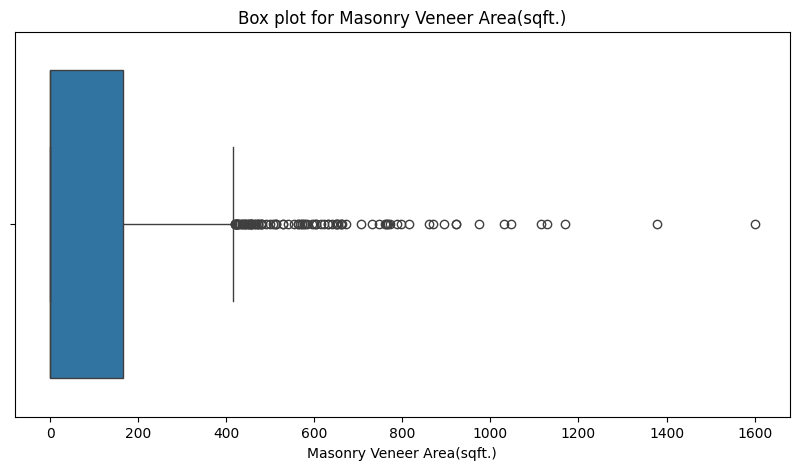

```python
# Box plot to check for outliers
visualize(plot='box',x='MasVnrArea',data=housing_data,xlabel='Masonry Veneer Area(sqft.)')
```

**Inspect `GarageYrBuilt` column**

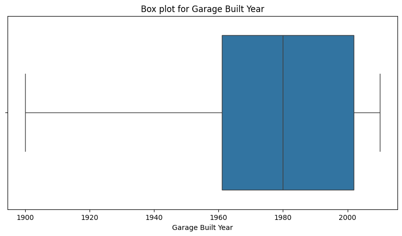

```python
# Box plot for GarageYrBuilt column
visualize(plot='box',x='GarageYrBlt',data=housing_data,xlabel='Garage Built Year')
```

Median value of year can be imputed for missing values.

**Inspect `MSSubClass` column**

From the data description, it seems `MSSubClass` column contains redundant information and does not offer any new information and can be dropped.

**Inspect `LotArea` column**

**Relation between `LotArea` and `SalePrice` with `LotConfig`**

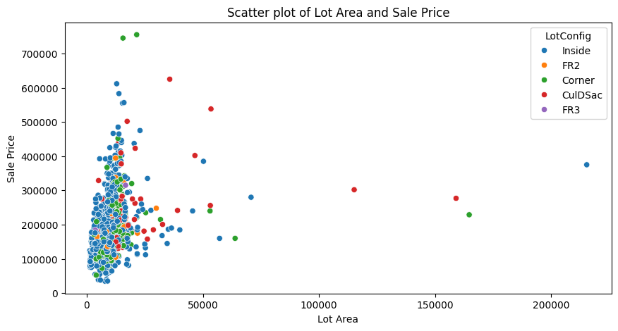

```python
# Scatter plot of LotArea and SalePrice with LotConfig
visualize(plot='scatter',x='LotArea',y='SalePrice',hue='LotConfig',data=housing_data,xlabel='Lot Area',ylabel='Sale Price')
```

`LotArea` column may be having outliers.

**Inspect `LotShape` column**

**Relation between `LotShape` and `SalePrice`**

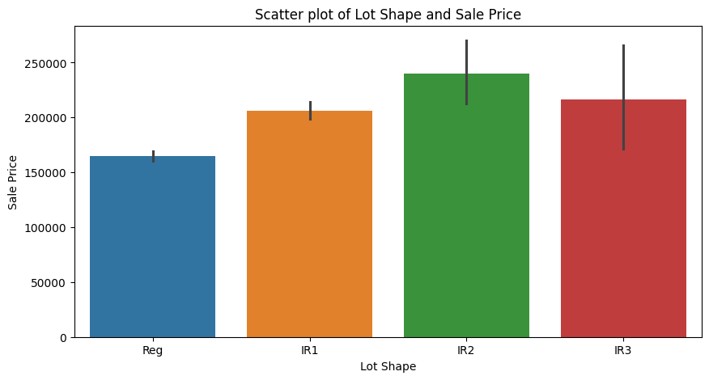

```python
# Bar plot of LotShape and SalePrice
visualize(plot='bar',x='LotShape',y='SalePrice',hue='LotShape',data=housing_data,xlabel='Lot Shape',ylabel='Sale Price')
```

Regular shaped houses are sold at less price than irregularly shaped houses.

**Inspect `LandContour` column**

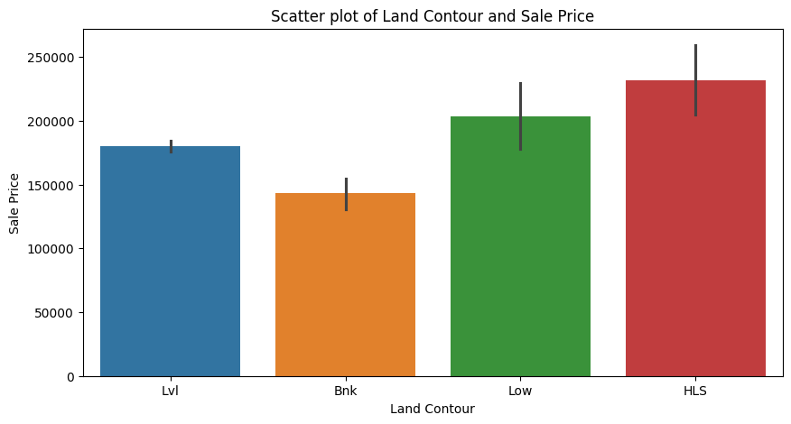

```python
# Bar plot of LandContour and SalePrice
visualize(plot='bar',x='LandContour',y='SalePrice',hue='LandContour',data=housing_data,xlabel='Land Contour',ylabel='Sale Price')
```

**Inspect `LotConfig` column**

**Relation between `LotConfig` and `SalePrice`**

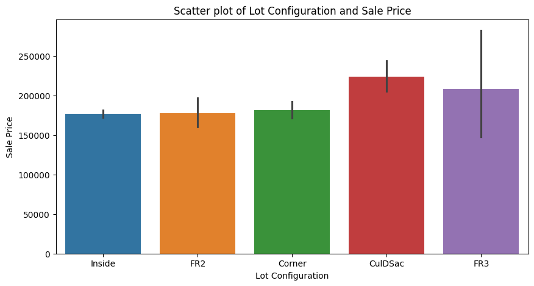

```python
# Bar plot of LotConfig and SalePrice
visualize(plot='bar',x='LotConfig',y='SalePrice',hue='LotConfig',data=housing_data,xlabel='Lot Configuration',ylabel='Sale Price')
```

`LotConfig` does not appear to be directly contributing to the sale price.

**Inspect `Neighborhood` column**

**Relation between `Neighborhood` and `SalePrice`**

[output not shown]

[output cut: 17 more lines]

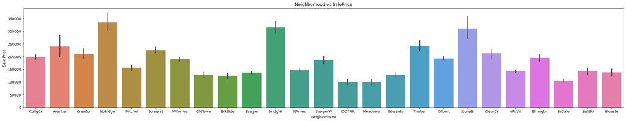

```python
# Bar plot of Neighborhood and SalePrice
fig=plt.figure(figsize=(30,5))
sns.barplot(x='Neighborhood',y='SalePrice',hue='Neighborhood',data=housing_data)
plt.xlabel('Neighborhood')
plt.ylabel('Sale Price')
plt.title('Neighborhood vs SalePrice')
plt.show()
```

**Inspect `Condition1` and `Condition2` columns**

From data description, `Condition1` and `Condition2` columns can be dropped and better features can be created from its values.

**Split Predictors and Target columns**

```python
y=housing_data['SalePrice']
X=housing_data.drop('SalePrice',axis=1)
```

```python
cols_to_drop=['Id','Alley','MasVnrType','PoolQC','Fence','MiscFeature','MSSubClass']
```

**Split Training and Test data**

```python
X_train,X_test,y_train,y_test=train_test_split(X,y,train_size=0.8,random_state=0)
```

```python
X_train=X_train.drop(cols_to_drop,axis=1)
```

```python
X_train.head()
```

|  | MSZoning | LotFrontage | LotArea | Street | LotShape | LandContour | Utilities | LotConfig | LandSlope | Neighborhood | ... | OpenPorchSF | EnclosedPorch | 3SsnPorch | ScreenPorch | PoolArea | MiscVal | MoSold | YrSold | SaleType | SaleCondition |
| --- | --- | --- | --- | --- | --- | --- | --- | --- | --- | --- | --- | --- | --- | --- | --- | --- | --- | --- | --- | --- | --- |
| 618 | RL | 90.0 | 11694 | Pave | Reg | Lvl | AllPub | Inside | Gtl | NridgHt | ... | 108 | 0 | 0 | 260 | 0 | 0 | 7 | 2007 | New | Partial |
| 870 | RL | 60.0 | 6600 | Pave | Reg | Lvl | AllPub | Inside | Gtl | NAmes | ... | 0 | 0 | 0 | 0 | 0 | 0 | 8 | 2009 | WD | Normal |
| 92 | RL | 80.0 | 13360 | Pave | IR1 | HLS | AllPub | Inside | Gtl | Crawfor | ... | 0 | 44 | 0 | 0 | 0 | 0 | 8 | 2009 | WD | Normal |
| 817 | RL | NaN | 13265 | Pave | IR1 | Lvl | AllPub | CulDSac | Gtl | Mitchel | ... | 59 | 0 | 0 | 0 | 0 | 0 | 7 | 2008 | WD | Normal |
| 302 | RL | 118.0 | 13704 | Pave | IR1 | Lvl | AllPub | Corner | Gtl | CollgCr | ... | 81 | 0 | 0 | 0 | 0 | 0 | 1 | 2006 | WD | Normal |

5 rows × 73 columns

```python
X_train.info()
```

```
<class 'pandas.core.frame.DataFrame'>
Index: 1168 entries, 618 to 684
Data columns (total 73 columns):
 #   Column         Non-Null Count  Dtype
---  ------         --------------  -----
 0   MSZoning       1168 non-null   object
 1   LotFrontage    956 non-null    float64
 2   LotArea        1168 non-null   int64
 3   Street         1168 non-null   object
 4   LotShape       1168 non-null   object
 5   LandContour    1168 non-null   object
 6   Utilities      1168 non-null   object
 7   LotConfig      1168 non-null   object
 8   LandSlope      1168 non-null   object
 9   Neighborhood   1168 non-null   object
```

[output cut: 65 more lines]

```python
y_train.head()
```

```
618    314813
870    109500
92     163500
817    271000
302    205000
Name: SalePrice, dtype: int64
```

**Impute missing values with median for numerical columns and mode for categorical columns**

```python
num_cols=[col for col in X.columns if X[col].dtype in ['int32','int64','float32','float64'] and col not in cols_to_drop]
print(num_cols)
cat_cols=[col for col in X.columns if X[col].dtype=='object' and col not in cols_to_drop]
print(cat_cols)
```

```
['LotFrontage', 'LotArea', 'OverallQual', 'OverallCond', 'YearBuilt', 'YearRemodAdd', 'MasVnrArea', 'BsmtFinSF1', 'BsmtFinSF2', 'BsmtUnfSF', 'TotalBsmtSF', '1stFlrSF', '2ndFlrSF', 'LowQualFinSF', 'GrLivArea', 'BsmtFullBath', 'BsmtHalfBath', 'FullBath', 'HalfBath', 'BedroomAbvGr', 'KitchenAbvGr', 'To…
['MSZoning', 'Street', 'LotShape', 'LandContour', 'Utilities', 'LotConfig', 'LandSlope', 'Neighborhood', 'Condition1', 'Condition2', 'BldgType', 'HouseStyle', 'RoofStyle', 'RoofMatl', 'Exterior1st', 'Exterior2nd', 'ExterQual', 'ExterCond', 'Foundation', 'BsmtQual', 'BsmtCond', 'BsmtExposure', 'BsmtF…
```

```python
num_imputer=SimpleImputer(strategy='median')
cat_imputer=SimpleImputer(strategy='most_frequent')
```

```python
X_train[num_cols]=num_imputer.fit_transform(X_train[num_cols])
X_train[cat_cols]=cat_imputer.fit_transform(X_train[cat_cols])
```

```python
X_train.head()
```

|  | MSZoning | LotFrontage | LotArea | Street | LotShape | LandContour | Utilities | LotConfig | LandSlope | Neighborhood | ... | OpenPorchSF | EnclosedPorch | 3SsnPorch | ScreenPorch | PoolArea | MiscVal | MoSold | YrSold | SaleType | SaleCondition |
| --- | --- | --- | --- | --- | --- | --- | --- | --- | --- | --- | --- | --- | --- | --- | --- | --- | --- | --- | --- | --- | --- |
| 618 | RL | 90.0 | 11694.0 | Pave | Reg | Lvl | AllPub | Inside | Gtl | NridgHt | ... | 108.0 | 0.0 | 0.0 | 260.0 | 0.0 | 0.0 | 7.0 | 2007.0 | New | Partial |
| 870 | RL | 60.0 | 6600.0 | Pave | Reg | Lvl | AllPub | Inside | Gtl | NAmes | ... | 0.0 | 0.0 | 0.0 | 0.0 | 0.0 | 0.0 | 8.0 | 2009.0 | WD | Normal |
| 92 | RL | 80.0 | 13360.0 | Pave | IR1 | HLS | AllPub | Inside | Gtl | Crawfor | ... | 0.0 | 44.0 | 0.0 | 0.0 | 0.0 | 0.0 | 8.0 | 2009.0 | WD | Normal |
| 817 | RL | 69.0 | 13265.0 | Pave | IR1 | Lvl | AllPub | CulDSac | Gtl | Mitchel | ... | 59.0 | 0.0 | 0.0 | 0.0 | 0.0 | 0.0 | 7.0 | 2008.0 | WD | Normal |
| 302 | RL | 118.0 | 13704.0 | Pave | IR1 | Lvl | AllPub | Corner | Gtl | CollgCr | ... | 81.0 | 0.0 | 0.0 | 0.0 | 0.0 | 0.0 | 1.0 | 2006.0 | WD | Normal |

5 rows × 73 columns

**Encode Categorical values**

```python
ordinal=['LotShape','Utilities','LandSlope','HouseStyle','ExterQual','ExterCond','BsmtQual','BsmtCond','BsmtExposure','BsmtFinType1','BsmtFinType2','HeatingQC','Electrical','KitchenQual','Functional',
'FireplaceQu','GarageFinish','GarageQual','GarageCond','PavedDrive']
```

```python
nominal=['MSZoning','Street','LandContour','LotConfig','Neighborhood','Condition1','Condition2',
'BldgType','RoofStyle','RoofMatl','Exterior1st','Exterior2nd','Foundation','Heating','CentralAir','GarageType','SaleType','SaleCondition']
```

```python
ordinal_encoder=OrdinalEncoder()
nominal_encoder=LabelEncoder()
```

**Encode Ordinal values**

```python
X_train[ordinal]=ordinal_encoder.fit_transform(X_train[ordinal])
```

**Encode Nominal values**

```python
for col in nominal:
    X_train[col]=nominal_encoder.fit_transform(X_train[col])
```

```python
X_train.head()
```

|  | MSZoning | LotFrontage | LotArea | Street | LotShape | LandContour | Utilities | LotConfig | LandSlope | Neighborhood | ... | OpenPorchSF | EnclosedPorch | 3SsnPorch | ScreenPorch | PoolArea | MiscVal | MoSold | YrSold | SaleType | SaleCondition |
| --- | --- | --- | --- | --- | --- | --- | --- | --- | --- | --- | --- | --- | --- | --- | --- | --- | --- | --- | --- | --- | --- |
| 618 | 3 | 90.0 | 11694.0 | 1 | 3.0 | 3 | 0.0 | 4 | 0.0 | 16 | ... | 108.0 | 0.0 | 0.0 | 260.0 | 0.0 | 0.0 | 7.0 | 2007.0 | 6 | 5 |
| 870 | 3 | 60.0 | 6600.0 | 1 | 3.0 | 3 | 0.0 | 4 | 0.0 | 12 | ... | 0.0 | 0.0 | 0.0 | 0.0 | 0.0 | 0.0 | 8.0 | 2009.0 | 8 | 4 |
| 92 | 3 | 80.0 | 13360.0 | 1 | 0.0 | 1 | 0.0 | 4 | 0.0 | 6 | ... | 0.0 | 44.0 | 0.0 | 0.0 | 0.0 | 0.0 | 8.0 | 2009.0 | 8 | 4 |
| 817 | 3 | 69.0 | 13265.0 | 1 | 0.0 | 3 | 0.0 | 1 | 0.0 | 11 | ... | 59.0 | 0.0 | 0.0 | 0.0 | 0.0 | 0.0 | 7.0 | 2008.0 | 8 | 4 |
| 302 | 3 | 118.0 | 13704.0 | 1 | 0.0 | 3 | 0.0 | 0 | 0.0 | 5 | ... | 81.0 | 0.0 | 0.0 | 0.0 | 0.0 | 0.0 | 1.0 | 2006.0 | 8 | 4 |

5 rows × 73 columns

**Mutual Information**

```python
discrete_features=X_train.dtypes==int
```

```python
def prep_mi_scores(X,y,discrete_features):
    mi_scores=mutual_info_regression(X=X,y=y,discrete_features=discrete_features)
    mi_scores=pd.Series(mi_scores,name='MI Scores',index=X.columns)
    mi_scores=mi_scores.sort_values(ascending=False)
    return mi_scores
```

```python
mi_scores=round(prep_mi_scores(X=X_train,y=y_train,discrete_features=discrete_features),3)
print(mi_scores)
```

```
OverallQual     0.563
Neighborhood    0.538
GrLivArea       0.485
TotalBsmtSF     0.396
GarageArea      0.392
                ...
3SsnPorch       0.000
MiscVal         0.000
MoSold          0.000
YrSold          0.000
Utilities       0.000
Name: MI Scores, Length: 73, dtype: float64
```

```python
mi_scores.unique()
```

```
array([0.563, 0.538, 0.485, 0.396, 0.392, 0.375, 0.369, 0.328, 0.314,
       0.309, 0.307, 0.306, 0.263, 0.25 , 0.232, 0.227, 0.226, 0.216,
       0.193, 0.175, 0.174, 0.171, 0.17 , 0.164, 0.158, 0.152, 0.15 ,
       0.132, 0.128, 0.121, 0.108, 0.106, 0.094, 0.091, 0.089, 0.085,
       0.078, 0.074, 0.067, 0.053, 0.05 , 0.049, 0.048, 0.042, 0.04 ,
       0.039, 0.033, 0.032, 0.031, 0.03 , 0.024, 0.02 , 0.014, 0.013,
       0.012, 0.011, 0.009, 0.007, 0.006, 0.004, 0.001, 0.   ])
```

```python
mi_scores[mi_scores>=0.2]
```

```
OverallQual     0.563
Neighborhood    0.538
GrLivArea       0.485
TotalBsmtSF     0.396
GarageArea      0.392
GarageCars      0.375
YearBuilt       0.369
1stFlrSF        0.328
GarageYrBlt     0.314
KitchenQual     0.309
BsmtQual        0.307
ExterQual       0.306
FullBath        0.263
YearRemodAdd    0.250
GarageFinish    0.232
LotFrontage     0.227
2ndFlrSF        0.226
Foundation      0.216
Name: MI Scores, dtype: float64
```

**Dump the Mutual Information scores in a pickle**

```python
with open('mi_scores.pkl','wb') as pkl:
    pickle.dump(mi_scores,pkl)
```